# R Notebook

Week 1 - Question 6

Internet privacy

1. Using read.csv(), load the dataset from AnonymityPoll.csv into a data frame called poll and summarize it with the summary() and str() unctions. How many people participated in the poll?

```r
summary(poll)
```

```
  Internet.Use      Smartphone         Sex           Age                 State           Region    Conservativeness Info.On.Internet
 Min.   :0.0000   Min.   :0.0000   Female:505   Min.   :18.00   California  :103   Midwest  :239   Min.   :1.000    Min.   : 0.000
 1st Qu.:1.0000   1st Qu.:0.0000   Male  :497   1st Qu.:37.00   Texas       : 72   Northeast:166   1st Qu.:3.000    1st Qu.: 2.000
 Median :1.0000   Median :1.0000                Median :55.00   New York    : 60   South    :359   Median :3.000    Median : 4.000
 Mean   :0.7742   Mean   :0.5078                Mean   :52.37   Pennsylvania: 45   West     :238   Mean   :3.277    Mean   : 3.795
 3rd Qu.:1.0000   3rd Qu.:1.0000                3rd Qu.:66.00   Florida     : 42                   3rd Qu.:4.000    3rd Qu.: 6.000
 Max.   :1.0000   Max.   :1.0000                Max.   :96.00   Ohio        : 38                   Max.   :5.000    Max.   :11.000
 NA's   :1        NA's   :43                    NA's   :27      (Other)     :642                   NA's   :62       NA's   :210
 Worry.About.Info Privacy.Importance Anonymity.Possible Tried.Masking.Identity Privacy.Laws.Effective
 Min.   :0.0000   Min.   :  0.00     Min.   :0.0000     Min.   :0.0000         Min.   :0.0000
 1st Qu.:0.0000   1st Qu.: 41.43     1st Qu.:0.0000     1st Qu.:0.0000         1st Qu.:0.0000
 Median :0.0000   Median : 68.75     Median :0.0000     Median :0.0000         Median :0.0000
 Mean   :0.4886   Mean   : 62.85     Mean   :0.3692     Mean   :0.1633         Mean   :0.2617
 3rd Qu.:1.0000   3rd Qu.: 88.89     3rd Qu.:1.0000     3rd Qu.:0.0000         3rd Qu.:1.0000
 Max.   :1.0000   Max.   :100.00     Max.   :1.0000     Max.   :1.0000         Max.   :1.0000
 NA's   :212      NA's   :215        NA's   :249        NA's   :218            NA's   :108
```

```r
str(poll)
```

```
'data.frame':   1002 obs. of  13 variables:
 $ Internet.Use          : int  1 1 0 1 0 1 1 0 0 1 ...
 $ Smartphone            : int  0 0 1 0 NA 1 0 0 NA 0 ...
 $ Sex                   : Factor w/ 2 levels "Female","Male": 2 2 1 2 1 2 1 1 2 1 ...
 $ Age                   : int  62 45 70 70 80 49 52 76 75 76 ...
 $ State                 : Factor w/ 49 levels "Alabama","Arizona",..: 20 39 29 10 10 41 21 31 32 32 ...
 $ Region                : Factor w/ 4 levels "Midwest","Northeast",..: 2 3 2 3 3 3 1 2 3 3 ...
 $ Conservativeness      : int  4 1 4 4 4 4 3 3 4 4 ...
 $ Info.On.Internet      : int  0 1 0 3 NA 6 3 NA NA 0 ...
 $ Worry.About.Info      : int  1 0 0 1 NA 0 1 NA NA 0 ...
 $ Privacy.Importance    : num  100 0 NA 88.9 NA ...
 $ Anonymity.Possible    : int  0 1 0 1 NA 1 0 NA NA 1 ...
 $ Tried.Masking.Identity: int  0 0 0 0 NA 1 0 NA NA 0 ...
 $ Privacy.Laws.Effective: int  0 1 NA 0 NA 0 1 NA 0 1 ...
```

2. Look at the breakdown of the number of people with smartphones using the table() command on the Smartphone variable.  How many interviewees responded that they use a smartphone?  How many interviewees responded that they don’t use a smartphone?  How many interviewees did not respond to the question, resulting in a missing value, or NA, in the summary() output?

```r
table(is.na(poll$Smartphone))
```

```
FALSE  TRUE
  959    43
```

487 have smartphone 472 no smartphone 43 NA

3. Look at the breakdown of the number of people with smartphones and Internet use using the table() command.  How many interviewees reported not having used the Internet and not having used a smartphone?  How many interviewees reported having used the Internet and having used a smartphone?  How many interviewees reported having used the Internet but not having used a smartphone?  How many interviewees reported having used a smartphone but not having used the Internet?

```r
table(poll$Smartphone[poll$Internet.Use==0])
```

```
  0   1
186  17
```

```r
table(poll$Smartphone[poll$Internet.Use==1])
```

```
  0   1
285 470
```

both no: 186 hv sm, no int: 17 no sm, hv int: 285 both yes: 470

4. Many of the response variables (Info.On.Internet, Worry.About.Info, Privacy.Importance, Anonymity.Possible, and Tried.Masking.Identity) were not collected if an interviewee does not use the Internet or a smartphone, meaning the variables will have missing values for these interviewees.  How many interviewees have a missing value for their Internet use?  How many interviewees have a missing value for their smartphone use?

```r
table(is.na(poll$Internet.Use))
```

```
FALSE  TRUE
 1001     1
```

```r
table(is.na(poll$Smartphone))
```

```
FALSE  TRUE
  959    43
```

1 for internet 43 for sm

5. Use the subset function to obtain a data frame called “, which is limited to interviewees who reported Internet use or who reported smartphone use. How many interviewees are in the new data frame?

```r
str(limited)
```

```
'data.frame':   792 obs. of  13 variables:
 $ Internet.Use          : int  1 1 0 1 1 1 1 1 1 1 ...
 $ Smartphone            : int  0 0 1 0 1 0 0 1 1 0 ...
 $ Sex                   : Factor w/ 2 levels "Female","Male": 2 2 1 2 2 1 1 1 1 2 ...
 $ Age                   : int  62 45 70 70 49 52 76 50 47 69 ...
 $ State                 : Factor w/ 49 levels "Alabama","Arizona",..: 20 39 29 10 41 21 32 45 32 31 ...
 $ Region                : Factor w/ 4 levels "Midwest","Northeast",..: 2 3 2 3 3 1 3 3 3 2 ...
 $ Conservativeness      : int  4 1 4 4 4 3 4 3 3 3 ...
 $ Info.On.Internet      : int  0 1 0 3 6 3 0 1 0 9 ...
 $ Worry.About.Info      : int  1 0 0 1 0 1 0 0 0 0 ...
 $ Privacy.Importance    : num  100 0 NA 88.9 88.9 ...
 $ Anonymity.Possible    : int  0 1 0 1 1 0 1 0 1 0 ...
 $ Tried.Masking.Identity: int  0 0 0 0 1 0 0 0 0 0 ...
 $ Privacy.Laws.Effective: int  0 1 NA 0 0 1 1 0 0 0 ...
```

792 interviewees

6. For all the remaining questions use the limited data frame you have created. Which variables have missing values in the limited data frame?

```r
summary(limited)
```

```
  Internet.Use      Smartphone         Sex           Age                   State           Region    Conservativeness Info.On.Internet
 Min.   :0.0000   Min.   :0.0000   Female:392   Min.   :18.00   California    : 89   Midwest  :172   Min.   :1.000    Min.   : 0.000
 1st Qu.:1.0000   1st Qu.:0.0000   Male  :400   1st Qu.:33.00   Texas         : 57   Northeast:128   1st Qu.:3.000    1st Qu.: 2.000
 Median :1.0000   Median :1.0000                Median :51.00   New York      : 45   South    :288   Median :3.000    Median : 4.000
 Mean   :0.9785   Mean   :0.6308                Mean   :48.57   Pennsylvania  : 33   West     :204   Mean   :3.237    Mean   : 3.795
 3rd Qu.:1.0000   3rd Qu.:1.0000                3rd Qu.:62.00   Florida       : 32                   3rd Qu.:4.000    3rd Qu.: 6.000
 Max.   :1.0000   Max.   :1.0000                Max.   :93.00   North Carolina: 28                   Max.   :5.000    Max.   :11.000
                  NA's   :20                    NA's   :22      (Other)       :508                   NA's   :45
 Worry.About.Info Privacy.Importance Anonymity.Possible Tried.Masking.Identity Privacy.Laws.Effective
 Min.   :0.0000   Min.   :  0.00     Min.   :0.0000     Min.   :0.0000         Min.   :0.0000
 1st Qu.:0.0000   1st Qu.: 41.43     1st Qu.:0.0000     1st Qu.:0.0000         1st Qu.:0.0000
 Median :0.0000   Median : 68.75     Median :0.0000     Median :0.0000         Median :0.0000
 Mean   :0.4886   Mean   : 62.85     Mean   :0.3692     Mean   :0.1633         Mean   :0.2559
 3rd Qu.:1.0000   3rd Qu.: 88.89     3rd Qu.:1.0000     3rd Qu.:0.0000         3rd Qu.:1.0000
 Max.   :1.0000   Max.   :100.00     Max.   :1.0000     Max.   :1.0000         Max.   :1.0000
 NA's   :2        NA's   :5          NA's   :39         NA's   :8              NA's   :65
```

Smartphone, Age, Conservativeness, WorryAboutInfo, PrivacyImportance, AnonymityPossible, TriedMaskingIdentity, PrivacyLawsEffective

7. What is the average number of pieces of personal information on the Internet, according to the Info.On.Internet variable? 3.795
8. How many interviewees reported a value of 0 for Info.On.Internet? How many interviewees reported the maximum value of 11 for Info.On.Internet?

```r
table(limited$Info.On.Internet)
```

```
  0   1   2   3   4   5   6   7   8   9  10  11
105  84  95 101 104  94  67  63  40  18  13   8
```

0 = 105 11 = 8

1. What proportion of interviewees who answered the Worry.About.Info question worry about how much information is available about them on the Internet?

```r
str(limited$Worry.About.Info)
```

```
 int [1:792] 1 0 0 1 0 1 0 0 0 0 ...
```

48.8%

10. What proportion of interviewees who answered the Anonymity.Possible question think it is possible to be completely anonymous on the Internet?

```r
278/(278+475)
```

```
[1] 0.3691899
```

36.9%

11. Build a histogram of the age of interviewees. What is the best represented age group in the population - people aged around 20, people aged around 40, people aged around 60, people aged around 80?

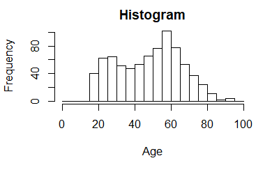

20: 20-30 60: 55-60 80: 80

12. Both Age and Info.On.Internet are variables that take on many values, so a good way to observe their relationship is through a graph. However, because Info.On.Internet takes on a small number of values, multiple points can be plotted in exactly the same location on this graph using the plot() function. What is the largest number of interviewees that have exactly the same value in their Age variable and the same value in their Info.On.Internet variable?

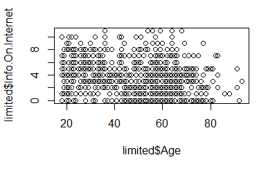

```r
plot(x=limited$Age,y=limited$Info.On.Internet)
```

```r
max(table(limited$Age,limited$Info.On.Internet))
```

```
[1] 6
```

```r
which.max(table(limited$Age,limited$Info.On.Internet))
```

```
[1] 36
```

6

13. To avoid points covering each other up, we can use the jitter() function on the values we pass to the plot function. Experimenting with the command jitter(c(1, 2, 3)), what appears to be the functionality of the jitter command?

```r
jitter(c(1, 2, 3))
```

```
[1] 0.8502481 1.9389736 2.9226385
```

add random deviations to the values such than rounding will give back the original values

14. Now, plot Age against Info.On.Internet with plot(jitter(limited$Age), jitter(limited$Info.On.Internet)). Comment on the relationship you observe between Age and Info.On.Internet?

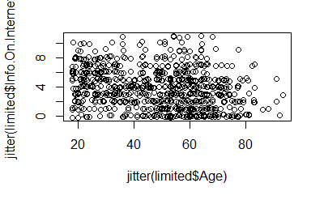

Younger ppl put more info regarding photoes etc. olderppl put name and contact and home etc.

15. Use the tapply() function to find the average of the Info.On.Internet value, depending on whether an interviewee is a smartphone user or not?

```r
tapply(limited$Info.On.Internet,limited$Smartphone,mean)
```

```
       0        1
2.922807 4.367556
```

if use smartphone user avg = 4.367 if not sm user then avg is = 2.922

16. Similarly use tapply to break down the Tried.Masking.Identity variable for smartphone and non-smartphone users.  What proportion of smartphone users who answered the Tried.Masking.Identity ques- tion have tried masking their identity when using the Internet?  What proportion of non-smartphone users who answered the Tried.Masking.Identity question have tried masking their identity when using the Internet?

```r
table(limited$Tried.Masking.Identity,limited$Smartphone)
```

```
      0   1
  0 248 390
  1  33  93
```

smarphone + mask = 93 non sm + try mask= 33

Week 2 - Question 6 Wines

1. Define two new variables age91 and age92 that captures the age of the wine (in years) at the time of the auctions. For example, a 1961 wine would have an age of 30 at the auction in 1991. What is the average price of wines that were 15 years or older at the time of the 1991 auction?

```r
mean(wine$price91[wine$age91>=15])
```

```
[1] 96.43563
```

2. What is the average price of the wines in the 1991 auction that were produced in years when both the harvest rain was below average and the temperature di erence was below average?

```r
mean(wine$price91[wine$hrain<mean(wine$hrain) & wine$tempdiff < mean(wine$tempdiff)])
```

```
[1] 72.86714
```

3. In this question, you will develop a simple linear regression model to t the log of the price at which the wine was auctioned in 1991 with the age of the wine. To t the model, use a training set with data for the wines up to (and including) the year 1981. What is the R-squared for this model?

```r
winetrain <- subset(wine,wine$vintage<=1981)
winetest <- subset(wine,wine$vintage>1981)
model1 <- lm(log(price91)~age91, data = winetrain)
summary(model1)
```

```
Call:
lm(formula = log(price91) ~ age91, data = winetrain)

Residuals:
     Min       1Q   Median       3Q      Max
-0.26897 -0.13328  0.01939  0.10452  0.41913

Coefficients:
            Estimate Std. Error t value Pr(>|t|)
(Intercept) 3.571442   0.144163  24.774 6.30e-16 ***
age91       0.042610   0.006899   6.176 6.19e-06 ***
---
Signif. codes:  0 ‘***’ 0.001 ‘**’ 0.01 ‘*’ 0.05 ‘.’ 0.1 ‘ ’ 1

Residual standard error: 0.1914 on 19 degrees of freedom
Multiple R-squared:  0.6675,    Adjusted R-squared:   0.65
F-statistic: 38.15 on 1 and 19 DF,  p-value: 6.188e-06
```

0.6675

4. Find the 99% con dence interval for the estimated coecients from the regression.

```r
confint(level=0.99,model1)
```

```
                 0.5 %     99.5 %
(Intercept) 3.15900093 3.98388288
age91       0.02287254 0.06234705
```

5. Use the model to predict the log of prices for wines made from 1982 onwards and auctioned in 1991. What is the test R-squared?

```r
winepred <- predict(model1,newdata=winetest)
summary(winepred)
```

```
   Min. 1st Qu.  Median    Mean 3rd Qu.    Max.
  3.827   3.859   3.891   3.891   3.923   3.955
```

```r
sse <- sum ((winepred - log(winetest$price91))^2 )
sst <- sum(( log(winetest$price91) - mean(log(winetrain$price91)) )^2)
1-sse/sst
```

```
[1] 0.9213742
```

6. Which among the following options describes best the quality of t of the model for this dataset in comparison with the Bordeaux wine dataset that was analyzed by Orley Ashenfelter?  The result indicates that the variation of the prices of the wines in this dataset is explained much less by the age of the wine in comparison to Bordeaux wines.  The result indicates that the variation of the prices of the wines in this dataset is explained much more by the age of the wine in comparison to Bordeaux wines.  The age of the wine has no predictive power on the wine prices in both the datasets.

2? what is the dataset????

7. Construct a multiple regression model to t the log of the price at which the wine was auctioned in 1991 with all the possible predictors (age91, temp, hrain, wrain, tem- pdi ) in the training dataset. To t your model, use the data for wines made up to (and including) the year 1981. What is the R-squared for the model?

```r
model2 <- lm(data=winetrain,log(price91)~age91+temp+hrain+wrain+tempdiff)
summary(model2)
```

```
Call:
lm(formula = log(price91) ~ age91 + temp + hrain + wrain + tempdiff,
    data = winetrain)

Residuals:
     Min       1Q   Median       3Q      Max
-0.32298 -0.07019 -0.01634  0.11051  0.24455

Coefficients:
              Estimate Std. Error t value Pr(>|t|)
(Intercept)  2.2626138  1.4914578   1.517   0.1532
age91        0.0482331  0.0075346   6.402 2.34e-05 ***
temp         0.1135015  0.0734344   1.546   0.1462
hrain       -0.0028825  0.0016205  -1.779   0.0987 .
wrain        0.0002520  0.0003918   0.643   0.5313
tempdiff    -0.1213280  0.1445947  -0.839   0.4166
---
Signif. codes:  0 ‘***’ 0.001 ‘**’ 0.01 ‘*’ 0.05 ‘.’ 0.1 ‘ ’ 1

Residual standard error: 0.1803 on 13 degrees of freedom
  (2 observations deleted due to missingness)
Multiple R-squared:  0.7938,    Adjusted R-squared:  0.7145
F-statistic: 10.01 on 5 and 13 DF,  p-value: 0.000421
```

0.7938

8. Is this model preferred to the model with only the age variable as a predictor (use the adjusted R-squared for the model to decide on this)?

Yes as the r2 value is larger

1. Which among the following best describes the output from the tted model?  The result indicates that less the temperature, the better is the price and quality of the wine  The result indicates that greater the temperature di erence, the better is the price and quality of wine.  The result indicates that lesser the harvest rain, the better is the price and quality of the wine.  The result indicates that winter rain is a very important variable in the t of the data.

10. Of the ve variables (age91, temp, hrain, wrain, tempdi ), drop the two variables that are the least signi cant from the results in (g). Rerun the linear regression and write down your tted model.

```r
model3 <- lm(data=winetrain,log(price91)~vintage+age91+temp+hrain)
summary(model3)
```

```
Call:
lm(formula = log(price91) ~ vintage + age91 + temp + hrain, data = winetrain)

Residuals:
     Min       1Q   Median       3Q      Max
-0.32198 -0.09905  0.00491  0.14536  0.29828

Coefficients: (1 not defined because of singularities)
             Estimate Std. Error t value Pr(>|t|)
(Intercept) 92.730516  13.086237   7.086 3.71e-06 ***
vintage     -0.045670   0.006702  -6.814 5.85e-06 ***
age91              NA         NA      NA       NA
temp         0.097500   0.068750   1.418    0.177
hrain       -0.001983   0.001236  -1.604    0.130
---
Signif. codes:  0 ‘***’ 0.001 ‘**’ 0.01 ‘*’ 0.05 ‘.’ 0.1 ‘ ’ 1

Residual standard error: 0.1752 on 15 degrees of freedom
  (2 observations deleted due to missingness)
Multiple R-squared:  0.7753,    Adjusted R-squared:  0.7304
F-statistic: 17.26 on 3 and 15 DF,  p-value: 3.973e-05
```

11. Is this model preferred to the model with all variables as predictors (use the adjusted R-squared in the training set to decide on this)?

model1: R2= 0.6675,adjR2=0.65 model2: R2= 0.7938,adjR2=0.7145 model3: R2= 0.7753,adjR2=0.7304

model 3 is preferred.

12. Using the variables identi ed in (j), construct a multiple regression model to t the log of the price at which the wine was auctioned in 1992 (remember to use age92 instead of age91). To t your model, use the data for wines made up to (and including) the year
1981. What is the R-squared for the model?

```r
model4 <- lm(data=winetrain,log(price92)~vintage+age92+temp+hrain)
summary(model4)
```

```
Call:
lm(formula = log(price92) ~ vintage + age92 + temp + hrain, data = winetrain)

Residuals:
     Min       1Q   Median       3Q      Max
-0.29394 -0.15545  0.03238  0.10221  0.37661

Coefficients: (1 not defined because of singularities)
             Estimate Std. Error t value Pr(>|t|)
(Intercept) 72.915598  15.861923   4.597 0.000349 ***
vintage     -0.035237   0.008124  -4.338 0.000586 ***
age92              NA         NA      NA       NA
temp         0.072494   0.083333   0.870 0.398043
hrain       -0.001539   0.001498  -1.027 0.320713
---
Signif. codes:  0 ‘***’ 0.001 ‘**’ 0.01 ‘*’ 0.05 ‘.’ 0.1 ‘ ’ 1

Residual standard error: 0.2123 on 15 degrees of freedom
  (2 observations deleted due to missingness)
Multiple R-squared:  0.5834,    Adjusted R-squared:  0.5001
F-statistic: 7.002 on 3 and 15 DF,  p-value: 0.003621
```

r-squared = 0.5834

13. Suppose in this application, we assume that a variable is statistically signi cant at the 0.2 level. Would you would reject the hypothesis that the coecient for the variable hrain is nonzero?

no insufficient evidence to reject at the 20% confidence level.

14. By separately estimating the equations for the wine prices for each auction, we can better establish the credibility of the explanatory variables because:  We have more data to t our models with.  The e ect of the weather variables and age of the wine (sign of the estimated coe- cients) can be checked for consistency across years.  1991 and 1992 are the markets when the Australian wines were traded heavily. Select the best option.

2????

15. The current t of the linear regression using the weather variables drops all observations where any of the entries are missing. Provide a short explanation on when this might not be a reasonable approach to use.

There might be some days where weather is not recorded but the other factors are important.

Week 3 - Question 2 Parole

1. Load the dataset Parole.csv into a data frame called Parole. How many parolees are contained in the dataset?

```r
str(paroles)
```

```
'data.frame':   675 obs. of  9 variables:
 $ Male            : int  1 0 1 1 1 1 1 0 0 1 ...
 $ RaceWhite       : int  1 1 0 1 0 0 1 1 1 0 ...
 $ Age             : num  33.2 39.7 29.5 22.4 21.6 46.7 31 24.6 32.6 29.1 ...
 $ State           : Factor w/ 4 levels "Kentucky","Louisiana",..: 3 3 3 3 3 3 3 3 3 3 ...
 $ TimeServed      : num  5.5 5.4 5.6 5.7 5.4 6 6 4.8 4.5 4.7 ...
 $ MaxSentence     : int  18 12 12 18 12 18 18 12 13 12 ...
 $ MultipleOffenses: int  0 0 0 0 0 0 0 0 0 0 ...
 $ Crime           : Factor w/ 4 levels "Driving","Drugs",..: 1 2 2 4 4 1 2 4 2 3 ...
 $ Violator        : int  0 0 0 0 0 0 0 0 0 0 ...
```

675 parolees

2. How many of the parolees in the dataset violated the terms of their parole?

```r
table(paroles$Violator)
```

```
  0   1
597  78
```

78 violators

Which variables in this dataset are unordered factors with at least three levels? To deal with unordered factors in a regression model, the standard practice is to define one level as the level" and create a binary variable for each of the remaining levels. In this way, a factor with n levels is replaced by n-1 binary variables. We will see this in question (e).

```r
str(paroles)
```

```
'data.frame':   675 obs. of  9 variables:
 $ Male            : int  1 0 1 1 1 1 1 0 0 1 ...
 $ RaceWhite       : int  1 1 0 1 0 0 1 1 1 0 ...
 $ Age             : num  33.2 39.7 29.5 22.4 21.6 46.7 31 24.6 32.6 29.1 ...
 $ State           : Factor w/ 4 levels "Kentucky","Louisiana",..: 3 3 3 3 3 3 3 3 3 3 ...
 $ TimeServed      : num  5.5 5.4 5.6 5.7 5.4 6 6 4.8 4.5 4.7 ...
 $ MaxSentence     : int  18 12 12 18 12 18 18 12 13 12 ...
 $ MultipleOffenses: int  0 0 0 0 0 0 0 0 0 0 ...
 $ Crime           : Factor w/ 4 levels "Driving","Drugs",..: 1 2 2 4 4 1 2 4 2 3 ...
 $ Violator        : int  0 0 0 0 0 0 0 0 0 0 ...
```

state and crime

4. To ensure consistent training/testing set splits, run the following 5 lines of code (do not include the line numbers at the beginning):
1. > set.seed(144)
2. > library(caTools)
3. > split < sample.split(Parole$Violator, SplitRatio = 0.7)
4. > train < subset(Parole, split == TRUE)
5. > test < subset(Parole, split == FALSE) Roughly what proportion of parolees have been allocated to the training and testing sets? Now, suppose you re-ran lines (1)-(5) again. What would you expect?  The exact same training/testing set split as the rst execution of (1)-(5)  A di erent training/testing set split from the rst execution of (1)-(5) If you instead ONLY re-ran lines (3)-(5), what would you expect?  The exact same training/testing set split as the rst execution of (1)-(5)  A di erent training/testing set split from the rst execution of (1)-(5) If you instead called set.seed() with a di erent number and then re-ran lines (3)-(5), what would you expect?  The exact same training/testing set split as the rst execution of (1)-(5)  A di erent training/testing set split from the rst execution of (1)-(5)

```r
set.seed(144)
library(caTools)
split  <- sample.split(paroles$Violator,SplitRatio = 0.7)
train  <- subset(paroles,split == TRUE)
test <- subset(paroles,split == FALSE)
```

same different different

5. Using glm, train a logistic regression model on the training set. Your dependent variable is “, and you should use all the other variables as independent variables. What variables are signi cant in this model? Signi cant variables should have a least one star, or should have a p-value less than 0.05.

```r
model1 <- glm(data=train,Violator~.,family=binomial)
summary(model1)
```

```
Call:
glm(formula = Violator ~ ., family = binomial, data = train)

Deviance Residuals:
    Min       1Q   Median       3Q      Max
-1.7041  -0.4236  -0.2719  -0.1690   2.8375

Coefficients:
                   Estimate Std. Error z value Pr(>|z|)
(Intercept)      -2.0361809  1.4474831  -1.407   0.1595
Male              0.3869904  0.4379613   0.884   0.3769
RaceWhite        -0.8867192  0.3950660  -2.244   0.0248 *
Age              -0.0001756  0.0160852  -0.011   0.9913
StateLouisiana    0.3916790  0.5719679   0.685   0.4935
StateOther       -0.4433007  0.4816619  -0.920   0.3574
StateVirginia    -3.8400884  0.6904894  -5.561 2.68e-08 ***
TimeServed       -0.1238867  0.1204230  -1.029   0.3036
MaxSentence       0.0802954  0.0553747   1.450   0.1470
MultipleOffenses  1.6119919  0.3853050   4.184 2.87e-05 ***
CrimeDrugs       -0.2663428  0.6412857  -0.415   0.6779
CrimeLarceny      0.6954770  0.6714835   1.036   0.3003
CrimeOther        0.0117627  0.5713035   0.021   0.9836
---
Signif. codes:  0 ‘***’ 0.001 ‘**’ 0.01 ‘*’ 0.05 ‘.’ 0.1 ‘ ’ 1

(Dispersion parameter for binomial family taken to be 1)

    Null deviance: 340.04  on 472  degrees of freedom
Residual deviance: 251.48  on 460  degrees of freedom
AIC: 277.48

Number of Fisher Scoring iterations: 6
```

6. What can we say based on the coecient of the MultipleO enses variable?  Our model predicts that parolees who committed multiple o enses have 1.61 times higher odds of being a violator than the average parolee.  Our model predicts that a parolee who committed multiple o enses has 1.61 times higher odds of being a violator than a parolee who did not commit multiple o enses but is otherwise identical.  Our model predicts that parolees who committed multiple o enses have 5.01 times higher odds of being a violator than the average parolee.  Our model predicts that a parolee who committed multiple o enses has 5.01 times higher odds of being a violator than a parolee who did not commit multiple o enses but is otherwise identical.

```r
exp(1.6119919)
```

```
[1] 5.012786
```

7. Consider a parolee who is male, of white race, aged 50 years at prison release, from Ken- tucky, served 3 months, had a maximum sentence of 12 months, did not commit multiple o enses, and committed a larceny.
- According to the model, what are the odds this individual is a violator?
- According to the model, what is the probability this individual is a violator?

```r
logodds <- -2.0361809 + 0.3869904 + -0.8867192 + -0.0001756*50 + -0.1238867*3 +0.0802954*12 + 0.6954770
logodds
```

```
[1] -1.257328
```

```r
exp(logodds)
```

```
[1] 0.284413
```

```r
1/(1+exp(-logodds))
```

```
[1] 0.2214342
```

8. Use the predict() function to obtain the model’s predicted probabilities for parolees in the test set. What is the maximum predicted probability of a violation?

```r
parolepred <- predict(newdata=test,model1,type="response")
```

[output not shown]

1. In the following questions, evaluate the model’s predictions on the test set using a thresh- old of 0.5. What is the model’s sensitivity? What is the model’s speci city? What is the model’s accuracy?

```r
table(parolepred >= 0.5, test$Violator)
```

```
          0   1
  FALSE 167  11
  TRUE   12  12
```

```r
 12/(11+12)
```

```
[1] 0.5217391
```

```r
  167/(167+12)
```

```
[1] 0.9329609
```

```r
  (167+12)/202
```

```
[1] 0.8861386
```

TPR (Sensitivity): TP/ (TP+FN) 12/(11+12) TNR (Specificity): TN/ (FP+TN) 167/(167+12) Overall Accuracy: (TP+TN)/ (TN+FN+FP+TP) (167+12)/202 = 0.886

10. What is the accuracy of a simple model that predicts that every parolee is a non-violator?

```r
table(parolepred >= 1, test$Violator)
```

```
          0   1
  FALSE 179  23
```

```r
179/202
```

```
[1] 0.8861386
```

11. Consider a parole board using the model to predict whether parolees will be violators or not. The job of a parole board is to make sure that a prisoner is ready to be released into free society, and therefore parole boards tend to be particularily concerned with releasing prisoners who will violate their parole. Which of the following most likely describes their preferences and best course of action?

> The board assigns more cost to a false negative than a false positive, and should therefore use a logistic regression cutoff less than 0.5. <
12. Which of the following is the most accurate assessment of the value of the logistic regression model with a cutoff 0.5 to a parole board, based on the model’s accuracy as compared to the simple baseline model?

> The model is likely of value to the board, and using a different logistic regression cutoff is likely to improve the model’s value.
13. Using the ROCR package, what is the AUC value for the model?

```r
library(ROCR)
ROCR_Predict <- prediction(parolepred, test$Violator)
```

[output not shown]

14. Describe the meaning of AUC in this context. > The probability the model can correctly di erentiate between a randomly selected parole violator and a randomly selected parole non-violator.
15. Our goal has been to predict the outcome of a parole decision, and we used a publicly available dataset of parole releases for predictions. In this nal problem, we’ll evaluate a potential source of bias associated with our analysis. It is always important to evaluate a dataset for possible sources of bias. The dataset contains all individuals released from parole in 2004, either due to completing their parole term or violating the terms of their parole. However, it does not contain parolees who neither violated their parole nor completed their term in 2004, causing non-violators to be underrepresented. This is called bias" or on the dependent variable," because only a subset of all relevant parolees were included in our analysis, based on our dependent variable in this analysis (parole violation). How could we improve our dataset to best address selection bias?

> We should use a dataset tracking a group of parolees from the start of their parole until either they violated parole or they completed their term.

Week 3 - Question 4

US Elections

1. Read the dataset into the dataframe pres. In the elections starting from 1916 up to and including 2012, which party has won more presidential elections? How many elections has that party won?

```r
table(pres$WIN)
```

```
-1  1
11 14
```

Democrats won more. 14 vs 11

2. Who among the nominees have represented the Democrats and the Republicans in the most number of presidential elections? How many times have they respectively done so?

```r
sort(table(pres$DEM))
```

```
      Cox     Davis   Dukakis      Gore  Humphrey   Johnson   Kennedy     Kerry  McGovern   Mondale     Smith    Truman    Wilson    Carter
        1         1         1         1         1         1         1         1         1         1         1         1         1         2
  Clinton     Obama Stevenson Roosevelt
        2         2         2         4
```

```r
sort(table(pres$REP))
```

```
  Coolidge       Dole       Ford  Goldwater    Harding     Hughes     Landon     McCain     Romney     Wilkie      Dewey Eisenhower
         1          1          1          1          1          1          1          1          1          1          2          2
    G.Bush   G.W.Bush     Hoover     Reagan      Nixon
         2          2          2          2          3
```

3 Nixon for REP 4 Roosevelt for DEM

3. Use a two-sided t-test to verify if there is evidence to show that the number of good quarters when the president is Republican is di erent from the number of good quarters when the president is Democratic. What is the p-value of the test and your conclusion?

```r
t.test(pres$GOOD[pres$WIN==1],pres$GOOD[pres$WIN==-1])
```

```
    Welch Two Sample t-test

data:  pres$GOOD[pres$WIN == 1] and pres$GOOD[pres$WIN == -1]
t = -0.99113, df = 22.419, p-value = 0.3322
alternative hypothesis: true difference in means is not equal to 0
95 percent confidence interval:
 -3.611899  1.274237
sample estimates:
mean of x mean of y
 4.285714  5.454545
```

p value = 0.3322 Insufficient evidence to show that good quarters are different.

4. Defne a new variable WININC that takes a value of 1 if the presidential nominee of the incumbent party wins and 0 otherwise. Provide the R command(s) that you used to create this variable.

```r
as.integer(pres$INC==pres$WIN)
```

```
 [1] 1 0 1 1 0 1 1 1 1 0 1 0 1 0 1 0 0 1 1 0 1 1 1 0 1
```

5. How many times did the presidential nominee from the incumbent party win and how many times did the presidential nominee from the incumbent party lose?

```r
table(pres$WININC)
```

```
 0  1
 9 16
```

incumbent won 16 times, lost 9 times

6. Perform a simple logistic regression to predict the WININC variable using the GROWTH variable and the constant. What is the log-likelihood value for the model?

```r
model1 <- glm(data=pres,WININC~GROWTH,family=binomial)
summary(model1)

-0.5*model1$deviance
2*(1+1)-2*(-0.5*model1$deviance)
```

[output not shown]

LL = (-0.5)*(Residual deviance) = -13.18257

7. The GROWTH variable is:
- Significant at the 0.1 level
8. Unlike questions (d) to (g) which looked at the incumbent party’s winning chances, from this point onwards, we are going to predict the chances of the Democratic party nominee winning in the presidential election. To do this, we need to transform the variables as follows:
1. Transform the WIN variable to be 1 when the presidential winner is a Democrat and 0 when the winner is a Republican.
2. Transform the GROWTH variable as follows: When the growth rate is positive (say 4.623) and the Republican party is incumbent, we should transform it to a negative value -4.623 since this should have a negative e ect on the Democratic nominee’s chances of winning while if the growth rate is negative (say -4.623) and the Republican party is incumbent, we should transform it to positive 4.623 since this should have a positive e ect on the Democratic nominee’s chances of winning. Write down the R command(s) for i and ii.

```r
presnew <- pres
presnew$WIN <- as.integer(presnew$WIN==1)

presnew$GROWTH <- pres$INC * presnew$GROWTH

presnew$GROWTH
```

[output not shown]

1. Repeat step ii in question (h) for the GOOD variable. You are now ready to develop a logistic regression model for the WIN variable using the predictor variables INC, RUN, DUR, GROWTH, GOOD and the constant (intercept). Use all the observations to build your model. What is the AIC of the model?

```r
presnew$GOOD <- pres$INC * presnew$GOOD
presnew$GOOD

model2 <- glm(data=presnew,WIN~+INC+RUN+DUR+GROWTH+GOOD,family=binomial)
summary(model2)
```

[output not shown]

AIC = 29.406

v(j) Among the predictor variables INC, RUN, DUR, GROWTH, GOOD and the constant (intercept), identify the three least signi cant variables?

intercept,INC,GOOD

11. Drop the three variables identi ed in question (j) and rebuild you logistic regression model. What is the AIC of the new model?

```r
model3 <- glm(data=presnew,WIN~RUN+DUR+GROWTH-1,family=binomial)
summary(model3)
```

[output not shown]

23.748

12. In this new model, what is the smallest signi cance level at which you would reject the null hypothesis that the coecient for the variable DUR is zero? Suppose, we now decide to use a level of 0.10, what would your suggestion be?

11%

13. Which among the two models that you have developed in questions (i) and (k) do you prefer? Explain your reasons briefly

14. We will now evaluate the probability of H.Clinton winning the 2016 election with this model where H.Clinton is the Democratic nominee and D.Trump is the Republican nominee. What should be the corresponding INC, RUN and DUR variables?

INC = 1 RUN = 0 DUR = 1

15. The forecasted growth rate from analysts of the U.S. economy for this year is 2%. Based on this, what is the probability of H.Clinton winning in the upcoming election based on the model you developed in question (11)?

GROWTH = 2

Logodds = -1.7852 + 2*0.4690 Odds = exp(logodds) prob = 1/1+(-logodds)

```r
(-1.7852) + (2*0.4690)
exp(-0.8472)/(1+exp(-0.8472))

1/(1+(exp(-(-1.7852 + 2*0.4690))))
```

[output not shown]

Week 4 & 5 Question 4

College

1. Split the data set into a training set and a test set using the seed 1 and the sample()function with 80% in the training set and 20% in the test set. How many observations are there in the training and test sets?

```r
college <- read.csv("../W4/0) Prac (W4 & W5)/College.csv")
str(college)

set.seed(1)
trainid <- sample(1:nrow(college),0.8*nrow(college))
testid <- -trainid
train<- college[trainid,]
test<- college[testid,]
str(test)
str(train)
```

[output not shown]

Train has 621 Test has 156

2. Fit a linear model using least squares on the training set. What is the average sum of squared error of the model on the training set? Report on the average sum of squared error on the test set obtained from the model.

```r
model1 <- lm(data=train, Apps~.)
summary(model1)

mean(model1$residuals^2)
```

[output not shown]

avg sse = 1,061,946

3. Use the backward stepwise selection method to select the variables for the regression model on the training set. Which is the first variable dropped from the set?

```r
library(leaps)
model3 <- regsubsets(Apps~.,college,nvmax=18,method="backward")
summod3 <- summary(model3)
summod3
```

[output not shown]

perc.alumni is the first to be dropped

4. Plot the adjusted R2 for all these models. If we choose the model based on the best adjusted R2 value, which variables should be included in the model?

```r
plot(summod3$adjr2)
max(summod3$adjr2)
chosen <- which.max(summod3$adjr2)
chosen
summod3$which[chosen,]
```

[output not shown]

Intercept+Private+Accept+Enroll+Top10perc+Top25perc+F.Undergrad+Outstate+Room.Board+PhD+S.F.Ratio+Expend+Grad.Rate

5. Use the model identi ed in part (d) to estimate the average sum of squared test error. Does this improve on the model in part (b) in the prediction accuracy?

```r
model4 <- lm(data=train, Apps~Private+Accept+Enroll+Top10perc+Top25perc+F.Undergrad+Outstate+Room.Board+PhD+S.F.Ratio+Expend+Grad.Rate
)

summary(model4)

model4pred <- predict(model4,newdata=test)

mean((test$Apps - model4pred)^2)
```

[output not shown]

6. Fit a LASSO model on the training set. Use the command to define the grid for : grid <- 10^ seq(10,-2, length=100) Plot the behavior of the coecients as  changes.

```r
library(glmnet)
grid <- 10^ seq(10,-2, length=100)
x <- model.matrix(Apps~.,college)
y <- college$Apps

modellasso <- glmnet(x[trainid,],y[trainid],lambda=grid)
plot(modellasso,xvar="lambda")
```

[output not shown]

7. Set the seed to 1 before running the cross-validation with LASSO to choose the best . Use 10-fold cross validation. Report the test error obtained, along with the number of non-zero coecient estimates.

```r
set.seed(1)

cvlasso <- cv.glmnet(x[trainid,],y[trainid])   #lambda=grid may help (default is NULL)
cvlasso$glmnet.fit
cvlasso$lambda.min

predictlassocv <- predict(modellasso,s=cvlasso$lambda.min,newx=x[testid,])

summary(predictlassocv)
cvlasso$nzero
cvlasso$glmnet.fit
```

[output not shown]

The best lambda is given as 0.4977024

Number of non-zero coefficients found with cvlasso$nzero, is 17, which uses all predictor varaibles.